## **Student’s Behavior Analysis**

#### Sonia Agarwal CS555(SUMMER O2) 8/18/2022

### **Research scenario and question(s)**

**The goal of the analysis is to draw assumptions regarding student activities such as:**

- Analysis of student’s behavior with different categorical variables finding answer.
- Gender wise Who spend more time on studying on a daily basis?
- Estimating the population mean of the College marks of students of universities by taking a random sample by using Central Limit Theorem.
- Calculating Least squares regression(Multiple Regression) equation that predicts Average Student College Mark from Height(cm),Weight(kg) and 12th.Mark.Formally testing (using the 5-step procedure) whether the set of these predictors are associated with Average Student College Mark at the α = 0.05 by performing the Global test.
- How many students are in each group? Summarize the data relating to both College.Mark and Department.
- Do the Average College Mark vary by Department?
- Perform a one way ANOVA using the aov or Anova function in R to assess. Use a significance level of α=0.05. Summarize the results using the 5-step procedure.
- If the results of the overall model are significant, perform the appropriate pairwise comparisons using Tukey’s procedure to adjust for multiple comparisons and summarize these results.

Create an appropriate number of dummy variables for department and re-run the one-way ANOVA using the lm function with the newly created dummy variables. Set BCA department as the reference group.

### **Dataset Overview**

The following data set contains information on 200+ university students. This data set is retrieved from Kaggle.This data set contains 19 different pieces of information such as gender, height, weight, 10th, 12th, grade, hobbies, daily study time, and more.

### **Data Prep**

The data provided held a lot of valuable information. As I mentioned earlier the data was downloaded from Kaggle in excel format as a csv. file.I transformed the data in new data frames and picked the desired columns for my research.This was so that multiple parts of the analysis could use the newly added data frame which is used throughout the analysis.The columns I used for my research analysis are Gender,Height,X12th.Mark,Weight,College.mark and willingness to pursue a degree carrier based on their degree. Here I created a new column named willingness for the purpose of changing character values with % sign to numeric data by taking 0.75 instead of 75%.I used Library(dplyr), library(plotly),library(knitr) for my analysis.I have uploaded the csv file on my github account and I am referencing that in R code. Formatted data set link: https://raw.githubusercontent.com/skashiv/cs555/main/Student_Behaviour.csv

Link to the original data set: https://www.kaggle.com/code/gunapro/eda-on-student-behavior/data?select=Student_Behaviour.csv

### **Statistical methods plan to use**

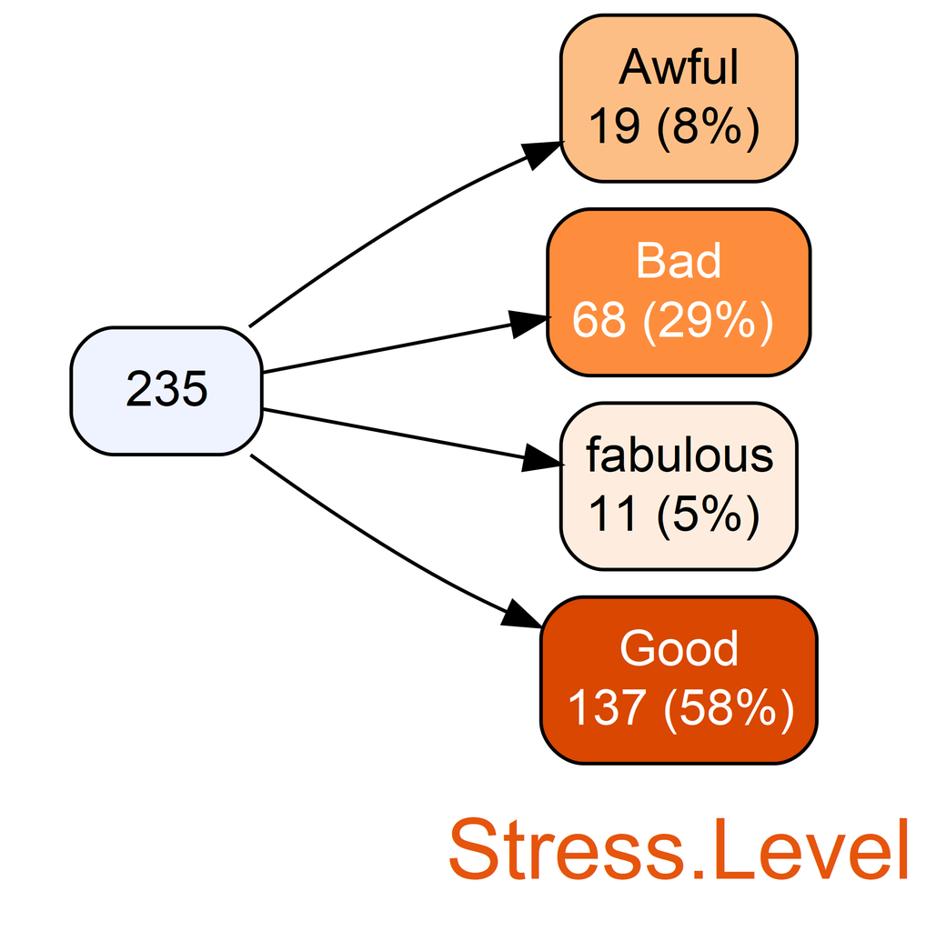

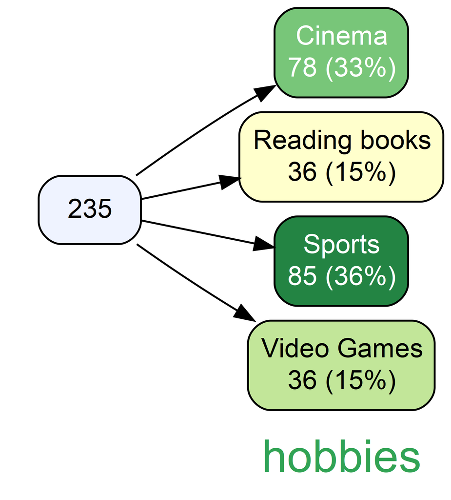

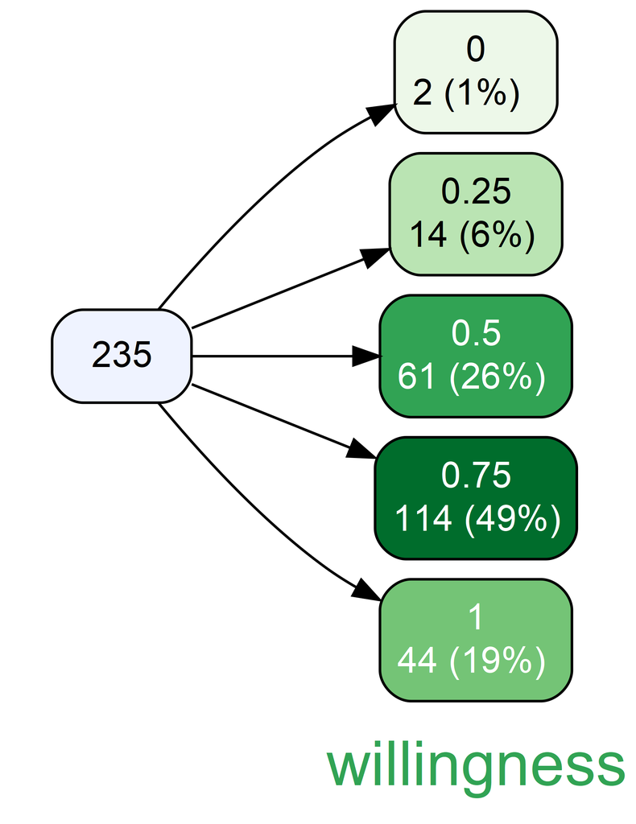

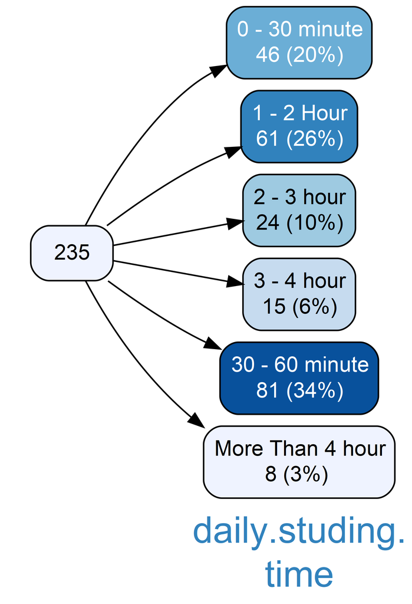

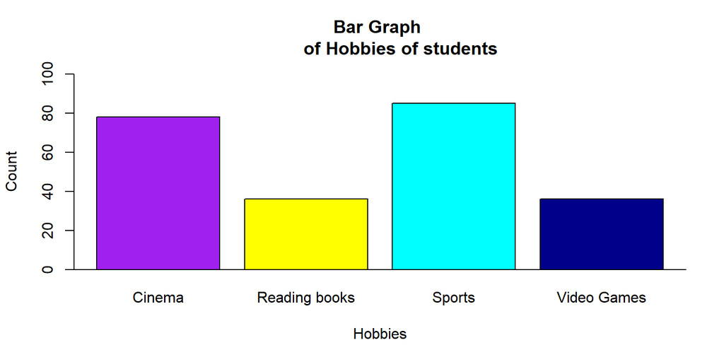

```
## daily.studing.time
##    0 - 30 minute       1 - 2 Hour       2 - 3 hour       3 - 4 hour
##               46               61               24               15
##   30 - 60 minute More Than 4 hour
##               81                8
```

```
## daily.studing.time
##    0 - 30 minute       1 - 2 Hour       2 - 3 hour       3 - 4 hour
##            19.57            25.96            10.21             6.38
##   30 - 60 minute More Than 4 hour
##            34.47             3.40
```

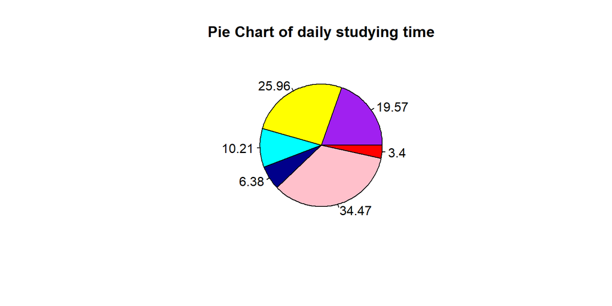

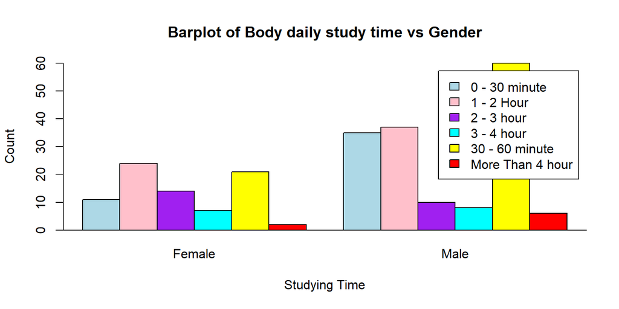

By looking at the plot more than 50% students having good feeling about their degree and college marks. Where as 5% students seems to be more happy and confident about their degree and career goals.

Hobbies wise there is a close percentage of students watching cinema and playing sports.Its interesting to know that there is same percentage of students who like to read books and playing video games.

Willingness of pursuing their career based on their degree wise percentage half of the of students perusing their career in their desired degree course.

Data is showing that at most students spent 30-60 minutes for daily study time.There is very less percentage of students who spent more then 4 hours for their study time.

### **Central Limit Theorem**

To estimate the population mean of the College marks of students of universities by taking a random sample.

The Central Limit Theorem states that the distribution of the sample means for a given sample size of the population has the shape of the normal distribution. The theorem is shown with various distributions of the input data in the following sections.” In other words, as the sample size gets larger, the means of the samples become a normal distribution. This was tested against the Average Student College Marks. Below is a figure showing the distributions of 5000 random samples of sample sizes of 10, 20, 30, and 40 with replacement is true and showed that the applicability of the Central Limit Theorem for this variable.With samples sizes of 10, 20, 30, and 40 histogram of sample means is verified.

By looking at the plots it is more likely that as the size of samples increasing histogram is showing more normal distribution. It tells us that as size increases, the distribution will look more and more like the normal distribution and that the variability will reduce.

```
##    Min. 1st Qu.  Median    Mean 3rd Qu.    Max.
##    1.00   60.00   70.00   70.66   80.00  100.00
```

```
## [1] 15.72745
```

```
## [1] 247.3526
```

[figure not shown]

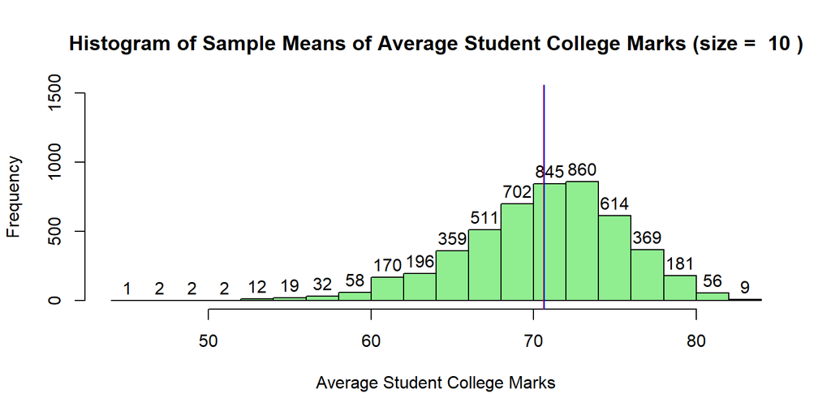

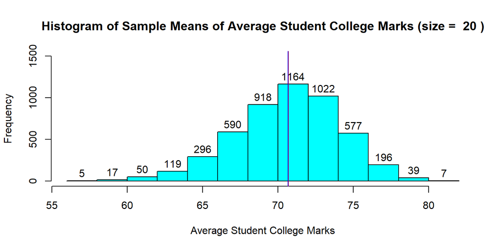

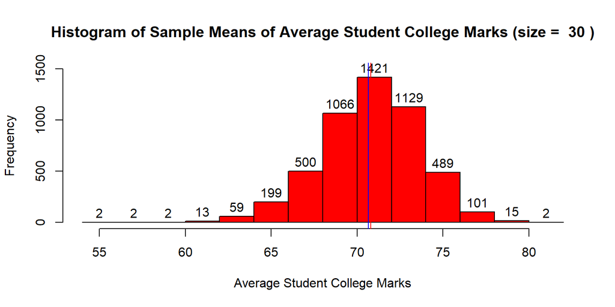

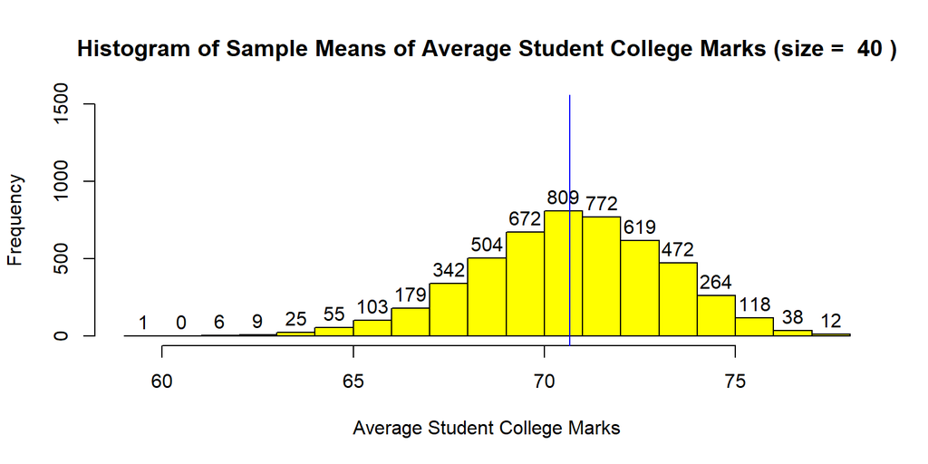

### **Least squares regression(Multiple Regression)**

Least squares regression(Multiple Regression) equation that predicts Average Student College Mark from Height(cm),Weight(kg) and 12th.Mark.

When fitting a multiple regression model, understanding the associations between each of the independent variables Height(cm),Weight(kg) and 12th.Mark with the dependent variable College Mark as well as the associations between independent variables is important. Let’s first look at a scatter plot matrix for Height(cm),Weight(kg) and 12th.Mark with the dependent variable College Mark.

```
##
## Call:
## lm(formula = college.mark ~ Height.CM. + Weight.KG. + X12th.Mark)
##
## Coefficients:
## (Intercept)   Height.CM.   Weight.KG.   X12th.Mark
##    25.22504      0.02779     -0.01810      0.61299
```

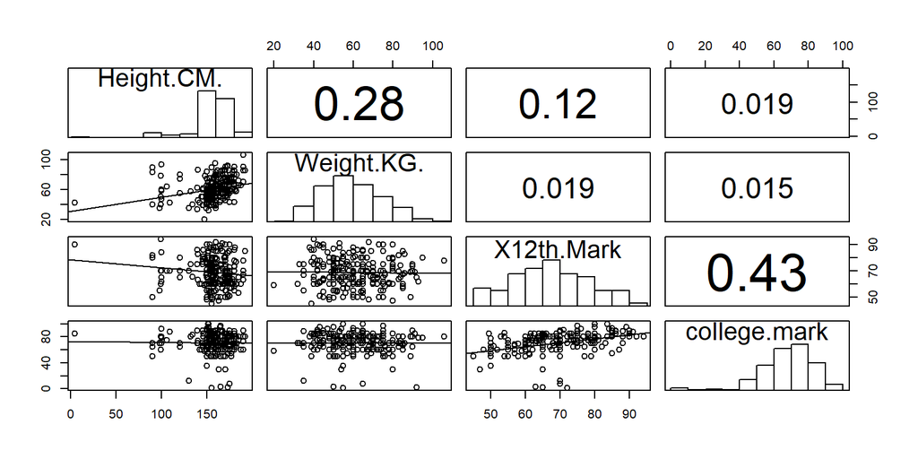

```
##               Height.CM.  Weight.KG.  X12th.Mark college.mark
## Height.CM.    1.00000000  0.27594837 -0.12067154  -0.01853459
## Weight.KG.    0.27594837  1.00000000 -0.01920847  -0.01490092
## X12th.Mark   -0.12067154 -0.01920847  1.00000000   0.42512280
## college.mark -0.01853459 -0.01490092  0.42512280   1.00000000
```

#### **Interpretation**

It can be seen from the graph and the correlation output values - There is weak association (0.27594837) between Height and Weight of the students.

### **Least square regression equation**

ŷ=25.22504 + 0.02779xHeight + -0.01810xWeight + 0.61299x12thMark

The regression equation’s main function is to predict the average or expected value of the Collge marks and the help understand the relationship. There is still randomness and variability in the response that plays into the actual response

Using summary(m) the value of adjusted R2 is 0.1715. Means there is, 17.15% of the variability that college marks can be explained by Height,weight and 12th marks of the student.

```
##
## Call:
## lm(formula = college.mark ~ Height.CM. + Weight.KG. + X12th.Mark)
##
## Residuals:
##     Min      1Q  Median      3Q     Max
## -71.673  -5.382   1.329   8.499  26.001
##
## Coefficients:
##             Estimate Std. Error t value        Pr(>|t|)
## (Intercept) 25.22504    9.82583   2.567          0.0109 *
## Height.CM.   0.02779    0.04559   0.610          0.5428
## Weight.KG.  -0.01810    0.06537  -0.277          0.7821
## X12th.Mark   0.61299    0.08558   7.162 0.0000000000105 ***
## ---
## Signif. codes:  0 '***' 0.001 '**' 0.01 '*' 0.05 '.' 0.1 ' ' 1
##
## Residual standard error: 14.32 on 231 degrees of freedom
## Multiple R-squared:  0.1821, Adjusted R-squared:  0.1715
## F-statistic: 17.14 on 3 and 231 DF,  p-value: 0.0000000004374
```

```r
qf(0.95,df1=3,df2=231)
```

```
## [1] 2.64368
```

#### **Hypothesis Testing (Test if set of these predictors are associated with College marks score at the α = 0.05.)**

1. **Set up the hypotheses and select the alpha level** This is equivalent to test whether all predictors combined can explained a significant portion of the variance of the outcome variable • H0 : βcollegemarks= βheight = βweight = β12th marks =0 (there is no linear association) • H1: βi≠0 for i = college marks, height, weight and 12th marks (there is a linear association, at least one of the slope coefficients is different than 0) • α=0.05
2. **Select the appropriate test statistic**

F=MS Reg/MS Res df = 3,n−k−1

3. **State the decision rule**

qf(0.95,df1=3,df2=231)

• Decision Rule: Reject H0 if F ≥ 2.64368 • Otherwise, do not reject H0

4. **Compute the test statistic**

   F value from the summary(m) F-statistic: 17.14 p-value: 0.0000000004374.
5. **Conclusion** Reject H0 since 17.14 ≥ 2.64368. We have significant evidence at the α=0.05 level that there is at least one slope coefficient that is different than zero. That is, there is evidence of a significant linear association between set of predictors with college marks. Here p<0.001 as calculated using software program). Using summary(m) the value of adjusted R2 is 0.1715. Means there is, 17.15% of the variability that college marks can be explained by Height, weight and 12th marks of students.

#### **Interpretation for 12th marks as Predictor after adjusting for height and weight**

Using Global F test and the table above, since 𝑝(0000000000105) ≤ 𝛼. We have significant evidence at the α=0.05 level that β12th marks ≠0 after controlling for height and weight. That is, 12th marks is a significant predictor of college marks after adjusting for height and weight (here, p<0.0001 as calculated using software program).

```
## Analysis of Variance Table
##
## Response: college.mark
##             Df Sum Sq Mean Sq F value           Pr(>F)
## Height.CM.   1     20    19.9  0.0970           0.7557
## Weight.KG.   1      6     6.0  0.0293           0.8643
## X12th.Mark   1  10514 10513.6 51.3010 0.00000000001052 ***
## Residuals  231  47341   204.9
## ---
## Signif. codes:  0 '***' 0.001 '**' 0.01 '*' 0.05 '.' 0.1 ' ' 1
```

Histogram of residuals is slightly normal and more skewed to the left.

```
##                   2.5 %     97.5 %
## (Intercept)  5.86533918 44.5847450
## Height.CM.  -0.06204109  0.1176220
## Weight.KG.  -0.14689869  0.1107009
## X12th.Mark   0.44436769  0.7816177
```

```
## [1] 235
```

```
## [1] 2.64368
```

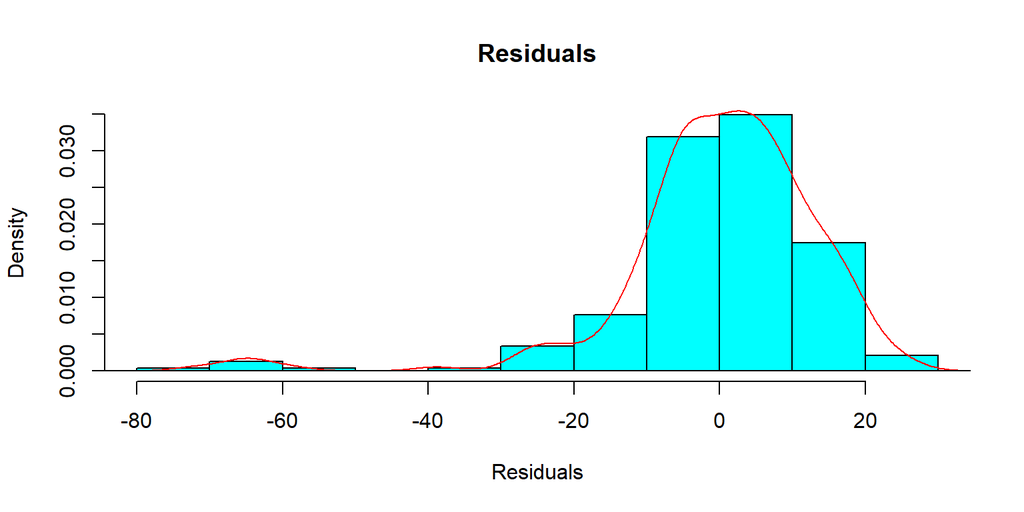

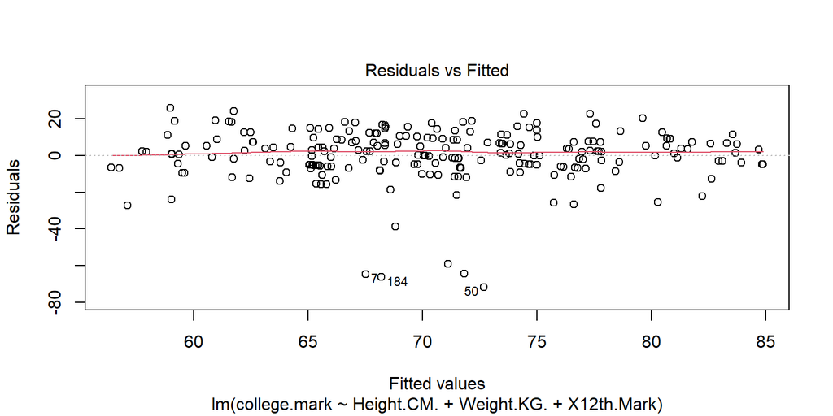

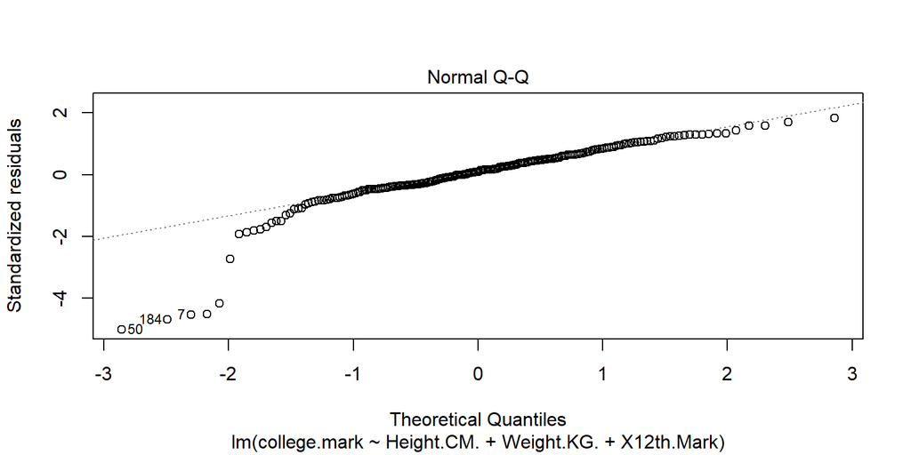

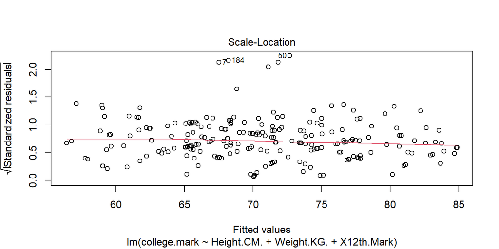

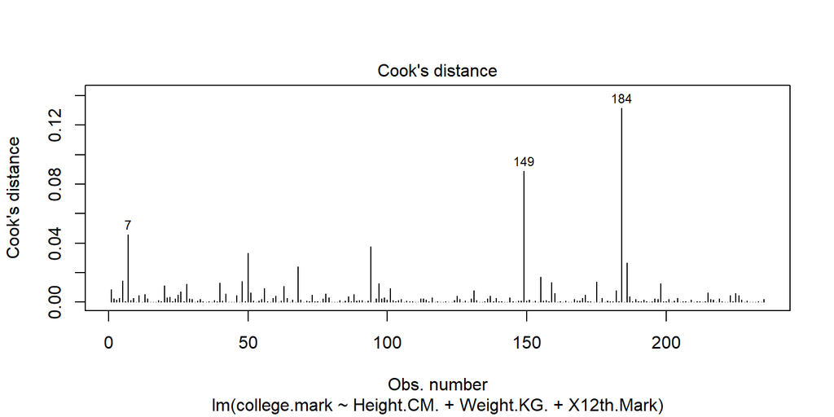

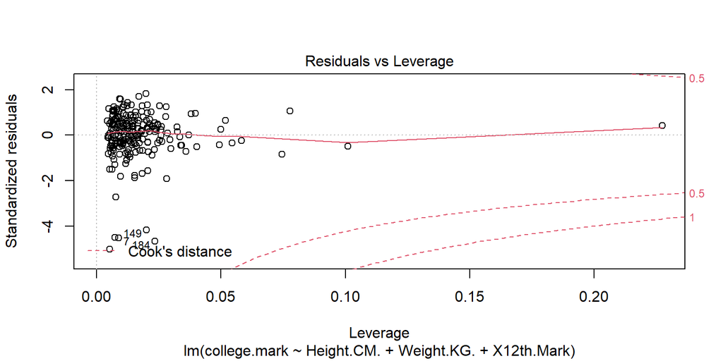

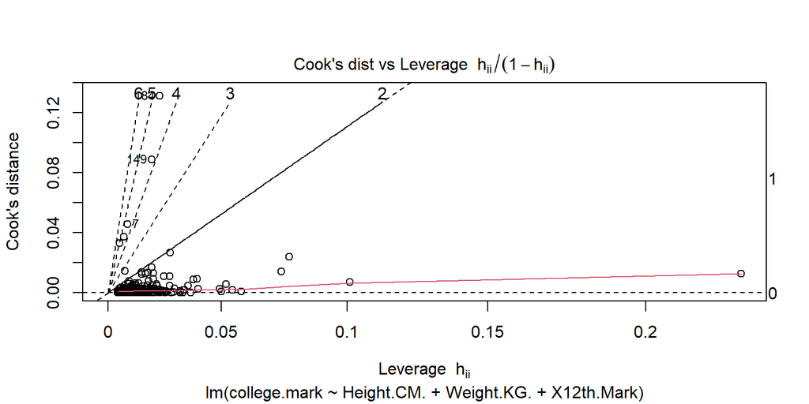

```
##   7  50  68  94 149 184 186
##   7  50  68  94 149 184 186
```

```
##     Gender Height.CM. Weight.KG. X12th.Mark college.mark       hobbies
## 5     Male      170.0         54         65         30.0   Video Games
## 7     Male      165.0         50         63          3.0 Reading books
## 26    Male       90.0         89         50         50.0        Sports
## 50    Male      155.0         55         72          1.0 Reading books
## 73  Female      160.0         35         75         89.0        Cinema
## 94    Male      175.0         65         70          7.5        Sports
## 97  Female        4.5         42         90         85.0        Cinema
## 149 Female      130.0         35         70         12.0 Reading books
## 184   Male      173.0         92         65          2.0        Cinema
## 186   Male      163.0         80         47         30.0        Cinema
##     daily.studing.time Financial.Status Stress.Level willingness
## 5       30 - 60 minute             good         Good        0.25
## 7           1 - 2 Hour             good         Good        0.75
## 26      30 - 60 minute             good          Bad        0.75
```

[output cut: 18 more lines]

```
##
## Call:
## lm(formula = college.mark ~ Height.CM. + Weight.KG. + X12th.Mark,
##     data = data_new)
##
## Residuals:
##      Min       1Q   Median       3Q      Max
## -27.9806  -6.7027   0.2927   6.8018  23.5098
##
## Coefficients:
##             Estimate Std. Error t value Pr(>|t|)
## (Intercept) 27.42007    7.57680   3.619 0.000367 ***
## Height.CM.   0.04237    0.03822   1.109 0.268778
## Weight.KG.  -0.01069    0.04875  -0.219 0.826608
## X12th.Mark   0.56556    0.06217   9.096  < 2e-16 ***
## ---
## Signif. codes:  0 '***' 0.001 '**' 0.01 '*' 0.05 '.' 0.1 ' ' 1
##
## Residual standard error: 10.15 on 221 degrees of freedom
## Multiple R-squared:  0.2727, Adjusted R-squared:  0.2629
## F-statistic: 27.62 on 3 and 221 DF,  p-value: 3.282e-15
```

#### **How many students are in each group? Summarize the data relating to both College.Mark and Department. Use appropriate numerical and/or graphical summaries?**

```
## [1] FALSE
```

```
## [1] TRUE
```

```
##                      Department   n
## 1 B.com Accounting and Finance   15
## 2                     B.com ISM  28
## 3                           BCA 132
## 4                      Commerce  60
```

### **Summarize the data relating to College Mark by the Department**

```
##                        Group.1        x
## 1                          BCA 67.93333
## 2                     Commerce 59.28571
## 3 B.com Accounting and Finance 69.91992
## 4                    B.com ISM 78.28000
```

```
##                        Group.1        x
## 1                          BCA 26.57998
## 2                     Commerce 16.24091
## 3 B.com Accounting and Finance 13.67210
## 4                    B.com ISM 12.41263
```

```
##                        Group.1        x
## 1                          BCA 706.4952
## 2                     Commerce 263.7672
## 3 B.com Accounting and Finance 186.9264
## 4                    B.com ISM 154.0735
```

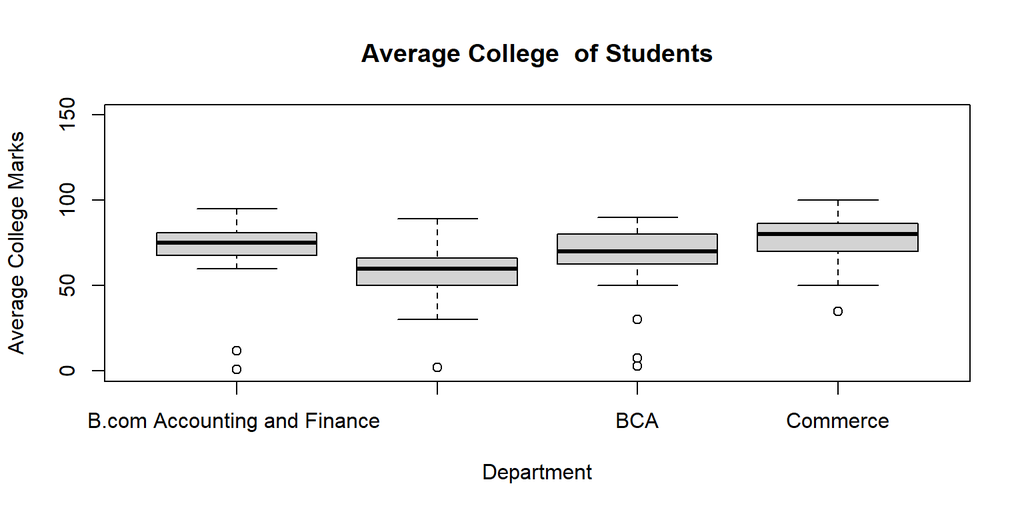

```
##              Df Sum Sq Mean Sq F value      Pr(>F)
## Depart        3   7290    2430    11.1 0.000000785 ***
## Residuals   231  50590     219
## ---
## Signif. codes:  0 '***' 0.001 '**' 0.01 '*' 0.05 '.' 0.1 ' ' 1
```

We can see that the overall p-value from the ANOVA table is 0.000000785. Since this is less than .05, we have sufficient evidence to say that the mean values across each departments are not equal. Thus, we can proceed to perform Tukey’s Test to determine exactly which department means are different.

### **5-step procedure**

1. **Set up the hypotheses and select the alpha level**

• H0:μB.com Accounting and Finance =μBCC =μCommerce= μB.com ISM (All underlying population means are equal) • H1:μi≠μj for some i and j (Not all of the underlying population means are equal) • α=0.05

As the results of the overall model are significant (null hypothesis is rejected), so we can perform the additional steps to determine which of the population Department means are different by using appropriate pairwise comparisons using Tukey’s procedure to adjust for multiple comparisons. Our confidence level to be 95%, which means we want our family-wise error rate to be 0.05. R gives us two metrics to compare each pairwise difference: 1. Confidence interval for the mean difference (given by the values of lwr and upr) 2. Adjusted p-value for the mean difference

#### **Pairwise t-test**

**Post-hoc test TukeyHSD - Test which of the groups have different means**

```
##   Tukey multiple comparisons of means
##     95% family-wise confidence level
##
## Fit: aov(formula = m1)
##
## $Depart
##                                             diff         lwr       upr
## Commerce-BCA                           -8.647619 -20.9014825  3.606244
## B.com Accounting and Finance-BCA        1.986591  -8.4483387 12.421521
## B.com ISM-BCA                          10.346667  -0.7086918 21.402025
## B.com Accounting and Finance-Commerce  10.634210   2.6660607 18.602359
## B.com ISM-Commerce                     18.994286  10.2293215 27.759250
## B.com ISM-B.com Accounting and Finance  8.360076   2.3972588 14.322893
##                                            p adj
## Commerce-BCA                           0.2636405
## B.com Accounting and Finance-BCA       0.9606679
## B.com ISM-BCA                          0.0757895
## B.com Accounting and Finance-Commerce  0.0036528
## B.com ISM-Commerce                     0.0000003
## B.com ISM-B.com Accounting and Finance 0.0019804
```

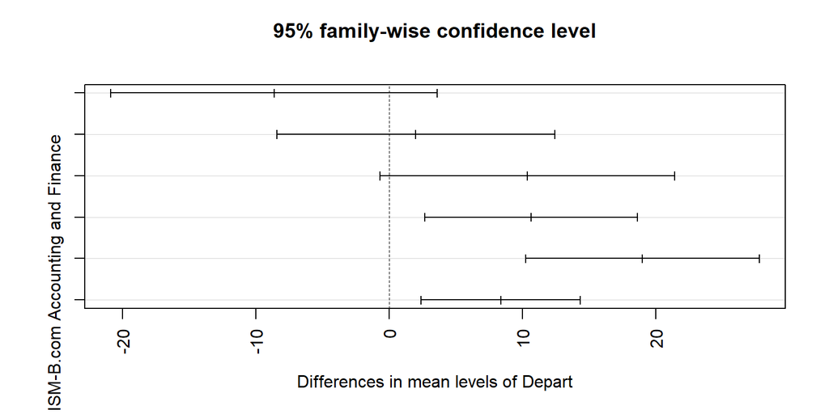

#### **Interpretation**

**Commerce-BCA** The 95% confidence interval for the mean difference between Commerce department and BCA department is (-20.9014825, 3.606244), and this interval contains zero so the difference between these two departments means is not statistically significant. Likewise, the adjusted p-value for the mean difference between Commerce department and BCA department is 0.2636405, which is greater than our significance level of 0.05, so this also indicates that the difference between these two departments means is not statistically significant.

**B.com ISM-BCA** The 95% confidence interval for the mean difference between B.com ISM and BCA is (-0.7086918, 21.402025), and this interval contains zero so the difference between these two departments means is not statistically significant. Likewise, the adjusted p-value for the mean difference between B.com ISM and BCA department is 0.0757895 which is greater than our significance level of 0.05, so this also indicates that the difference between these two departments means is not statistically significant.

**Accounting and Finance-Commerce** The 95% confidence interval for the mean difference between Accounting and Finance and Commerce department is (2.6660607, 18.602359), and since this interval doesn’t contain zero we know that the difference between these two departments means is statistically significant.Likewise, the adjusted p-value for the mean difference between Accounting and Finance and Commerce is 0.0036528, which is less than our significance level of 0.05, so this also indicates that the difference between these two department means is statistically significant.

**B.com ISM-Commerce**

The 95% confidence interval for the mean difference between B.com ISM and Commerce department is (10.2293215, 27.759250), and since this interval doesn’t contain zero we know that the difference between these two departments means is statistically significant.Likewise, the adjusted p-value for the mean difference between B.com ISM-Commerce is 0.0000003, which is less than our significance level of 0.05, so this also indicates that the difference between these two department means is statistically significant.

**B.com ISM-B.com Accounting and Finance** The 95% confidence interval for the mean difference between B.com ISM-B.com Accounting and Finance department is (2.3972588, 14.322893), and since this interval doesn’t contain zero we know that the difference between these two departments means is statistically significant.Likewise, the adjusted p-value for the mean difference between B.com ISM-B.com Accounting and Finance is 0.0019804, which is less than our significance level of 0.05, so this also indicates that the difference between these two department means is statistically significant.

### **Creating an appropriate number of dummy variables**

Create an appropriate number of dummy variables for department and re-run the one-way ANOVA using the lm function with the newly created dummy variables. Set BCA department as the reference group.

First need to create the dummy variables. We need (# of departments - 1)3 dummy variables.

```
##
## Call:
## lm(formula = college.mark ~ data1$gBCAccounting + data1$gBCISM +
##     data1$gCommerce, data = data1)
##
## Residuals:
##    Min     1Q Median     3Q    Max
## -66.93  -8.28   1.72  10.08  29.71
##
## Coefficients:
##                     Estimate Std. Error t value Pr(>|t|)
## (Intercept)           67.933      3.821  17.779   <2e-16 ***
## data1$gBCAccounting    1.987      4.032   0.493   0.6227
## data1$gBCISM          10.347      4.272   2.422   0.0162 *
## data1$gCommerce       -8.648      4.735  -1.826   0.0691 .
## ---
## Signif. codes:  0 '***' 0.001 '**' 0.01 '*' 0.05 '.' 0.1 ' ' 1
##
## Residual standard error: 14.8 on 231 degrees of freedom
## Multiple R-squared:  0.126,  Adjusted R-squared:  0.1146
## F-statistic:  11.1 on 3 and 231 DF,  p-value: 0.0000007852
```

**The regression model in this case taking BCA department as reference group is given by**

y = 67.933+ 1.987DepartmentBCAccounting +10.347 DepartmentBCISM -8.648DepartmentCommerce

The intercept β0 (the sample mean in the reference group i. e.BCA department is 67.933 when all the other departments having value zero. The estimated difference in department mean between BCA Accounting and reference department BCA is 1.987 and the t value is 0.493. p-value for the mean difference between BCA Accounting and reference department BCA is 0.6227, which is not statistically significant.

The estimated difference in department mean between B.COM ISM and reference department BCA is 10.347 and the t value is 2.422. p-value for the mean difference between B.COM ISM and reference department BCA is 0.0162, which is statistically significant. The estimated difference in department mean between Commerce and reference department BCA is -8.648 and the t value is -1.826. p-value for the mean difference between Commerce and reference department BCA is 0.0691, which is not statistically significant.It is slightly deviated from the alpha value 0.05.

Adjusted r squared value is 0.1146 which is telling that linear model explains 11.46% of the variability.It is not explaining much about the variability between the departments.